# Eric_Hirsch_607_DataScienceInContext

Eric Hirsch

2021-04-15

## **Principle 1: Style is substance**

Elegance and style are not superfluous to or, even worse, antithetical to good data design - they are central to readability and clarity.

Consider the elegance of this table:

**Principle 2. Form is function**

Placement, color, width - all express meaning If it’s a side comment, put it on the side. For example, this would be a good place to make a side comment about the table to the left.

| Airline | Status | Los.Angeles | Phoenix | San.Diego | San.Francisco | Seattle |
| --- | --- | --- | --- | --- | --- | --- |
| ALASKA | on time | 497 | 221 | 212 | 503 | 1841 |
| NA | delayed | 62 | 12 | 20 | 102 | 305 |
| AMWEST | on time | 694 | 4840 | 383 | 320 | 201 |
| NA | delayed | 117 | 415 | 65 | 129 | 61 |

**Principle 3. Less is more**

## Why a box?

Consider this box plot. What dos the box actually get you? What is the ratio of data expression to ink?

This boxplot is great for analysis …

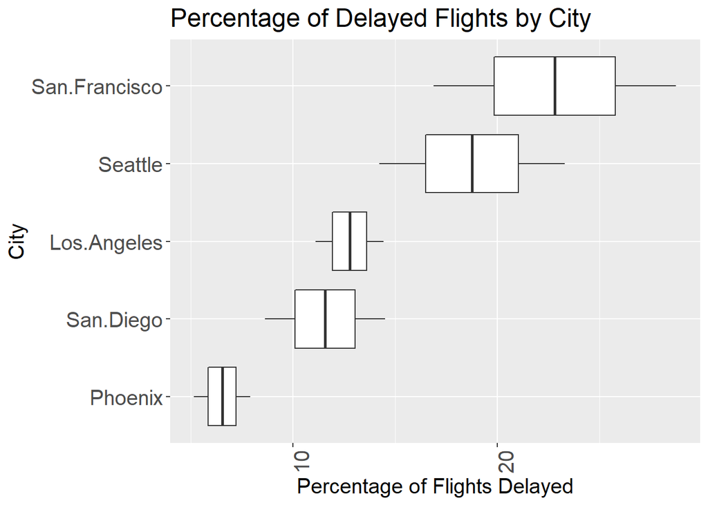

… but this is cleaner, leaner and perhaps clearer for a presentation.

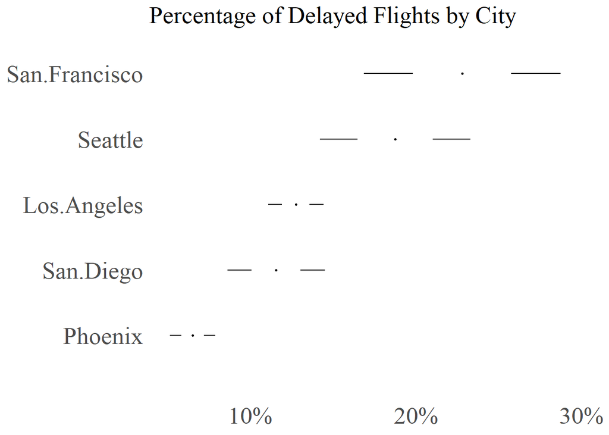

*Or consider this example:*

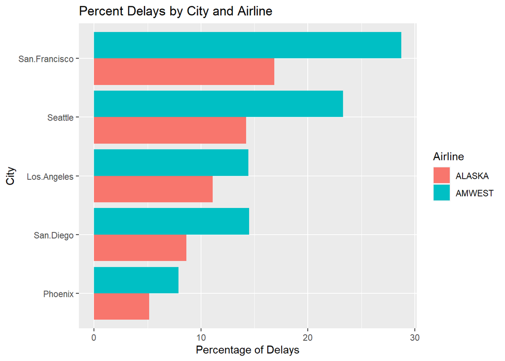

… to this:

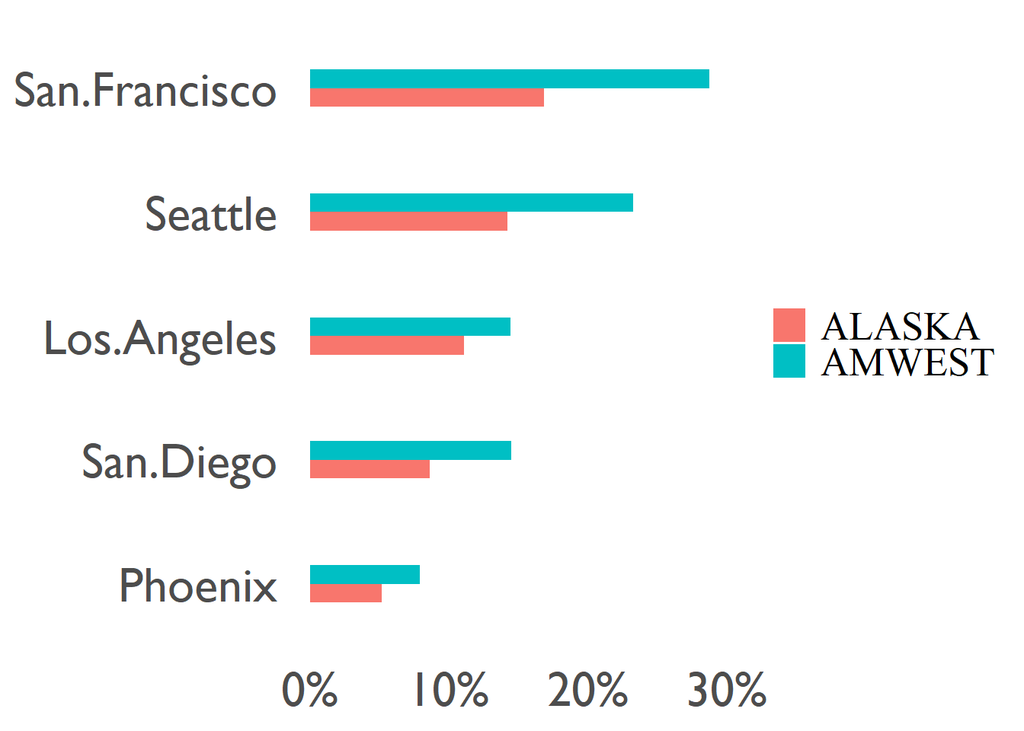

Fig.1: Percent delays by city and airline

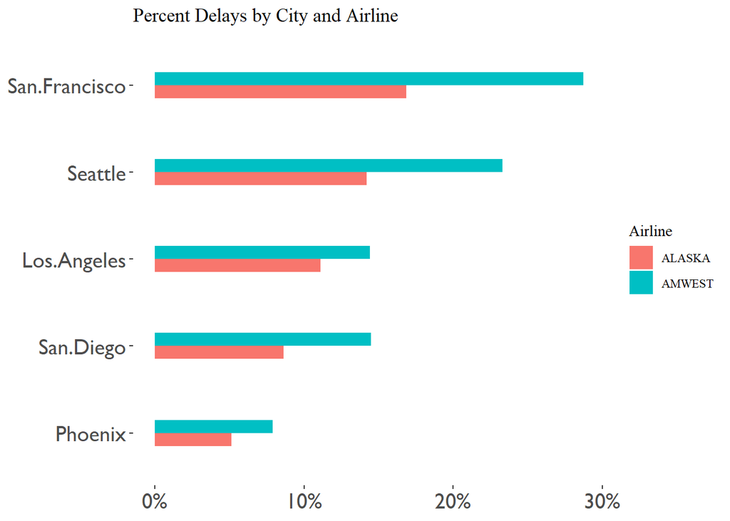

**Principle 4. Pictures are words**

Consider these sparklines - they are graphical words.

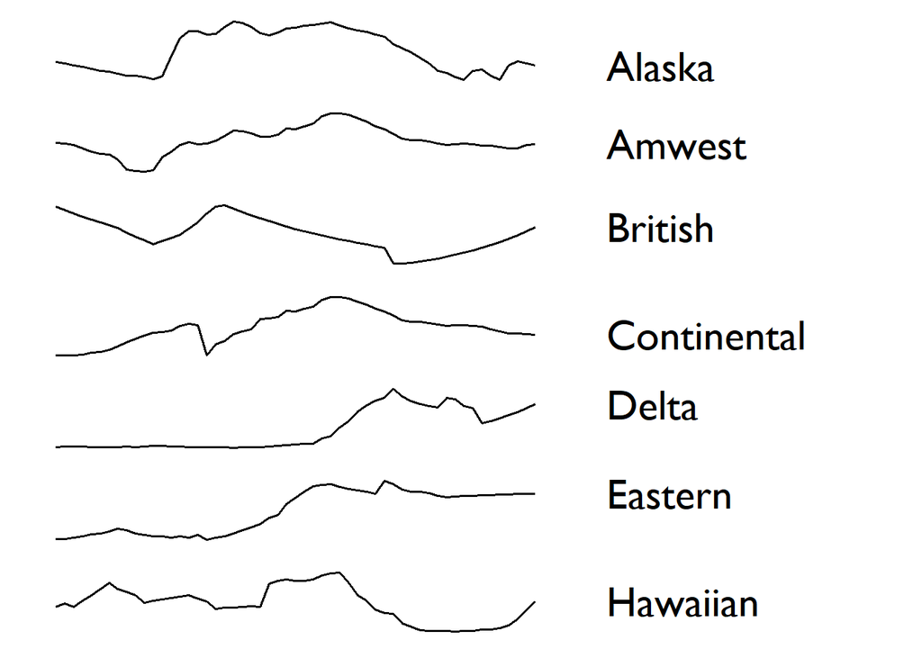

In R we can put more data into a sparkline if we want to. Here we see IQR and min/max graphed onto a sparkline:

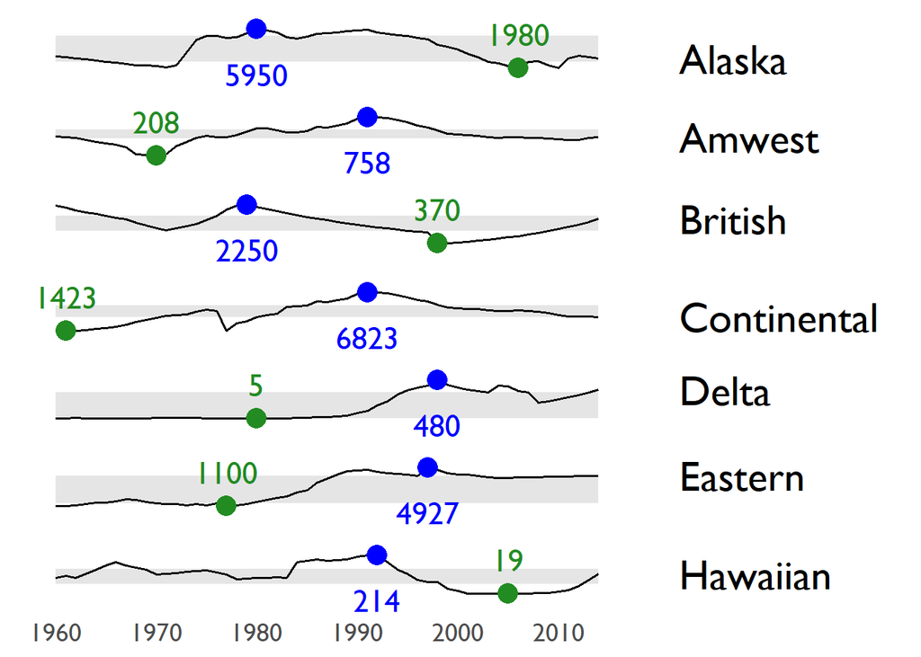

Tufte invented the sparkline - a small graph that shows the upward and downward trajectory of some variable in a small, concise graphical statement. For Tufte, the sparkline functions just as a word does - small, discrete representation meant to express a single - though complex - idea.

**Principle 5. Get off the grid**

In the graph below, the lines are the same as in a line graph. But the y axis has been obliterated - instead, it is occupied by the names of airlines on either side with their traffic shown at various points. It is as if the sparkline words had been arranged in a paragraph. It is a very small change but a highly effective one:

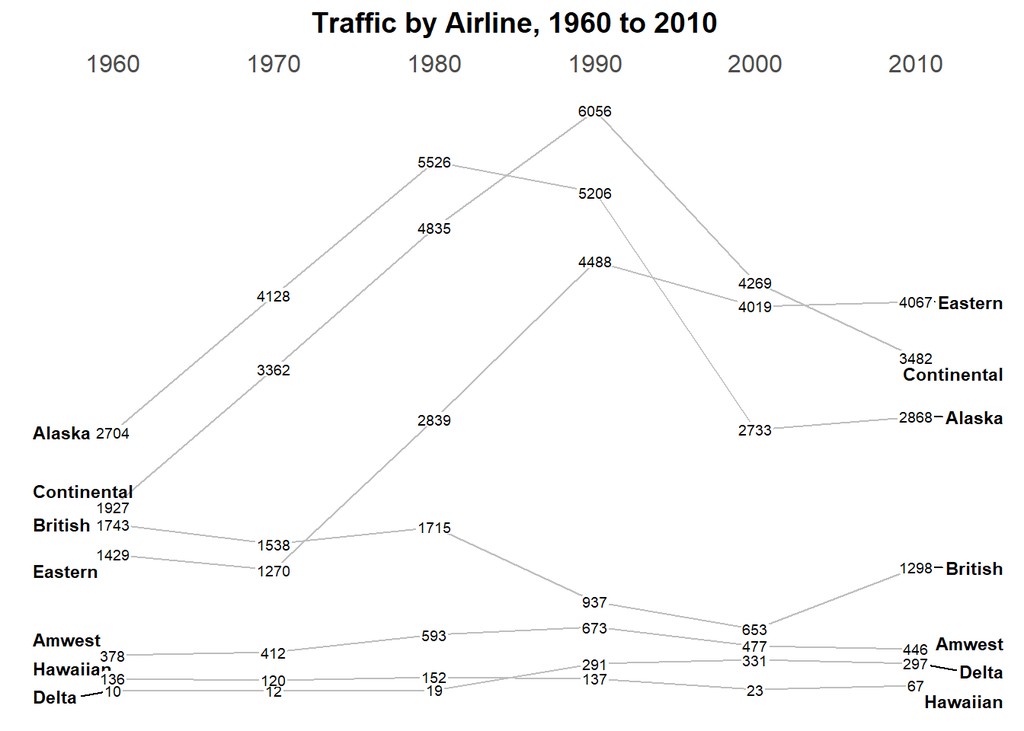

## **Packages**

Basic style, background color, font and sidebar: *tufte*

Boxplot: geom_boxplot() with ggplot2 *ggthemes*

Minimal ink: theme_tufte() *ggthemes*

Minimal Barchart *ggplot2*

Sparklines: *sparkline*

Slopegraph: *slopegraph*